# 5. 企业破产预警与财务风险识别

## 一、实验简介

本实验围绕 **企业破产预警（Corporate Bankruptcy Prediction）** 场景展开，使用 Logistic 回归、支持向量机（SVM）、随机森林（Random Forest）和 XGBoost 四种模型，基于企业财务报表指标识别企业是否进入财务困境或破产状态，并从**解释性**与**预测性**两个维度比较模型表现。

**为什么企业破产预警如此重要？**

1. **信贷风险管理**：银行在发放企业贷款前需要评估企业的违约概率，破产预警模型是核心工具。
2. **投资决策**：投资者需要识别潜在的"地雷股"，避免投资于即将破产的企业。
3. **监管合规**：金融监管机构要求对系统性风险进行持续监测，企业破产预警是其中的关键环节。

**为什么同时使用四种模型？**

| 模型 | 解释性 | 预测性 | 适用场景 |
| --- | --- | --- | --- |
| **Logistic 回归** | ⭐⭐⭐⭐⭐ | ⭐⭐ | 监管报告、系数解释 |
| **SVM** | ⭐⭐ | ⭐⭐⭐ | 高维小样本场景 |
| **Random Forest** | ⭐⭐⭐ | ⭐⭐⭐⭐ | 稳健预测 + 特征重要性 |
| **XGBoost** | ⭐⭐⭐ | ⭐⭐⭐⭐⭐ | 追求最优预测性能 |

本实验使用 **UCI Polish Companies Bankruptcy Data** 数据集，通过 scikit-learn 的 OpenML 接口获取。

该数据集关于波兰企业破产预测，破产企业分析期为 2000–2012 年，存续企业评估期为 2007–2013 年。

数据包含 64 个财务比率特征，涵盖多个预测年份子集。

## 二、实验目标

- 理解 Logistic 回归如何通过 **对数几率（Log-Odds）** 将线性模型用于分类，并通过系数符号与大小解释变量影响方向。
- 掌握 SVM 的 **最大间隔（Maximum Margin）** 思想，以及核函数（Kernel）如何处理非线性问题。
- 理解随机森林的 **Bagging + 特征随机采样** 机制与 XGBoost 的 **梯度提升残差拟合** 策略。
- 学会处理 **严重类别不平衡（~5% 破产 vs ~95% 存续）** 和 **大量缺失值** 的实际数据问题。
- 从解释性与预测性两个维度系统比较四种模型，输出企业破产预警报告。

## 三、实验要求

- 使用 OpenML 获取 Polish Companies Bankruptcy 数据集。
- 完成数据预处理：缺失值填充、异常值处理、类别不平衡应对。
- 分别构建 Logistic 回归、SVM、Random Forest 和 XGBoost 模型。
- 对四个模型进行系统性评估与对比（重点关注 AUC-ROC 和 Recall）。
- 提取关键财务变量，生成财务指标解释图和破产预警报告。

## 四、思考提示

1. 在极端不平衡的数据（破产企业仅占 ~5%）中，Accuracy 还有参考价值吗？
2. Logistic 回归的系数为正/为负分别意味着什么？如何据此给出财务建议？
3. SVM 使用 RBF 核时，为什么必须先对特征进行标准化？
4. 随机森林和 XGBoost 在处理缺失值方面有什么不同？
5. 如果你是银行的风控经理，你会选择哪个模型部署？为什么？

## 1. 环境准备

```python
from __future__ import annotations

import warnings

import matplotlib.pyplot as plt
import numpy as np
import pandas as pd
import seaborn as sns
import xgboost as xgb
from matplotlib import font_manager
from sklearn.datasets import fetch_openml
from sklearn.ensemble import RandomForestClassifier
from sklearn.impute import SimpleImputer
from sklearn.linear_model import LogisticRegression
from sklearn.metrics import (
    accuracy_score, precision_score, recall_score, f1_score,
    roc_auc_score, roc_curve, confusion_matrix, classification_report,
)
from sklearn.model_selection import train_test_split
from sklearn.pipeline import make_pipeline
from sklearn.preprocessing import StandardScaler
from sklearn.svm import SVC

warnings.filterwarnings("ignore")
```

接下来配置中文字体，确保图表中的中文标签能正确显示：

```python
def configure_plot_fonts() -> None:
    """配置 matplotlib 中文字体，避免 seaborn 主题覆盖字体设置。"""
    sns.set_theme(style="whitegrid")
    font_candidates = [
        "Microsoft YaHei", "SimHei", "Noto Sans CJK SC",
        "PingFang SC", "WenQuanYi Zen Hei",
    ]
    available_fonts = {f.name for f in font_manager.fontManager.ttflist}
    selected_font = next(
        (name for name in font_candidates if name in available_fonts), None
    )
    if selected_font is None:
        warnings.warn(
            "未检测到常见中文字体，图表中文可能显示为方块。"
            "建议安装 'Microsoft YaHei' 或 'Noto Sans CJK SC'。",
            UserWarning,
        )
        plt.rcParams["font.sans-serif"] = ["DejaVu Sans"]
    else:
        plt.rcParams["font.sans-serif"] = [selected_font, "DejaVu Sans"]
    plt.rcParams["axes.unicode_minus"] = False


configure_plot_fonts()
```

## 2. 数据集加载与预处理

### 2.1 使用 OpenML 获取 Polish Bankruptcy 数据

我们通过 scikit-learn 的 `fetch_openml` 接口获取 Polish Companies Bankruptcy 数据集的第 3 年子集（`polish-bankruptcy-3-year`）。该子集包含第 3 年的财务比率，预测企业在 3 年后是否破产。

**为什么选第 3 年子集？** 它在样本量（约 10500 条）和预测时间跨度（3 年）之间取得了较好平衡，既有足够的样本训练模型，又有实际的预警提前量。

```python
# Ref: https://scikit-learn.org/stable/modules/generated/sklearn.datasets.fetch_openml.html
# 获取 Polish Bankruptcy 3rd Year 数据集
# 该数据集在 OpenML 上的名称为 "polish-bankruptcy-3-year"
bankruptcy_data = fetch_openml(
    name="polish-bankruptcy-3-year", version=1, as_frame=True, parser="auto"
)

df = bankruptcy_data.frame
target_col = bankruptcy_data.target_names[0] if bankruptcy_data.target_names else "class"

print(f"数据集维度：{df.shape}")
print(f"目标变量：{target_col}")
print(f"目标变量分布：\n{df[target_col].value_counts()}")
print(f"破产企业比例：{(df[target_col] == '1').mean():.4f}")
```

```
数据集维度：(10503, 65)
目标变量：class
目标变量分布：
class
0    10008
1      495
Name: count, dtype: int64
破产企业比例：0.0471
```

### 2.2 了解数据结构

该数据集包含 64 个财务比率特征（Attr1–Attr64），均为数值类型。以下是部分关键指标的含义：

[output not shown]

```python
print(f"特征名称：{list(df.columns[:10])} ... (共 {df.shape[1] - 1} 个特征)")
print(f"\n前 5 行数据：")
display(df.head())
```

```
特征名称：['Attr1', 'Attr2', 'Attr3', 'Attr4', 'Attr5', 'Attr6', 'Attr7', 'Attr8', 'Attr9', 'Attr10'] ... (共 64 个特征)

前 5 行数据：
```

|  | Attr1 | Attr2 | Attr3 | Attr4 | Attr5 | Attr6 | Attr7 | Attr8 | Attr9 | Attr10 | ... | Attr56 | Attr57 | Attr58 | Attr59 | Attr60 | Attr61 | Attr62 | Attr63 | Attr64 | class |
| --- | --- | --- | --- | --- | --- | --- | --- | --- | --- | --- | --- | --- | --- | --- | --- | --- | --- | --- | --- | --- | --- |
| 0 | 0.174190 | 0.41299 | 0.14371 | 1.3480 | -28.9820 | 0.60383 | 0.219460 | 1.1225 | 1.1961 | 0.46359 | ... | 0.163960 | 0.375740 | 0.83604 | 0.000007 | 9.7145 | 6.2813 | 84.291 | 4.3303 | 4.0341 | 0 |
| 1 | 0.146240 | 0.46038 | 0.28230 | 1.6294 | 2.5952 | 0.00000 | 0.171850 | 1.1721 | 1.6018 | 0.53962 | ... | 0.027516 | 0.271000 | 0.90108 | 0.000000 | 5.9882 | 4.1103 | 102.190 | 3.5716 | 5.9500 | 0 |
| 2 | 0.000595 | 0.22612 | 0.48839 | 3.1599 | 84.8740 | 0.19114 | 0.004572 | 2.9881 | 1.0077 | 0.67566 | ... | 0.007639 | 0.000881 | 0.99236 | 0.000000 | 6.7742 | 3.7922 | 64.846 | 5.6287 | 4.4581 | 0 |
| 3 | 0.024526 | 0.43236 | 0.27546 | 1.7833 | -10.1050 | 0.56944 | 0.024526 | 1.3057 | 1.0509 | 0.56453 | ... | 0.048398 | 0.043445 | 0.95160 | 0.142980 | 4.2286 | 5.0528 | 98.783 | 3.6950 | 3.4844 | 0 |
| 4 | 0.188290 | 0.41504 | 0.34231 | 1.9279 | -58.2740 | 0.00000 | 0.233580 | 1.4094 | 1.3393 | 0.58496 | ... | 0.176480 | 0.321880 | 0.82635 | 0.073039 | 2.5912 | 7.0756 | 100.540 | 3.6303 | 4.6375 | 0 |

5 rows × 65 columns

### 2.3 缺失值分析

真实的财务数据往往存在大量缺失值——某些企业未披露特定财务指标，或者指标计算过程中出现分母为零等情况。我们需要先了解缺失情况，再决定填充策略。

```python
missing_pct = df.drop(columns=[target_col]).isnull().mean().sort_values(ascending=False)
print(f"存在缺失的特征数：{(missing_pct > 0).sum()} / {len(missing_pct)}")
print(f"\n缺失率最高的 10 个特征：")
print(missing_pct.head(10).apply(lambda x: f"{x:.2%}"))
```

```
存在缺失的特征数：44 / 64

缺失率最高的 10 个特征：
Attr37    45.09%
Attr21     7.68%
Attr27     6.81%
Attr60     5.64%
Attr45     5.63%
Attr54     2.17%
Attr28     2.17%
Attr53     2.17%
Attr64     2.17%
Attr24     2.16%
dtype: str
```

将缺失率可视化，直观判断哪些特征缺失严重：

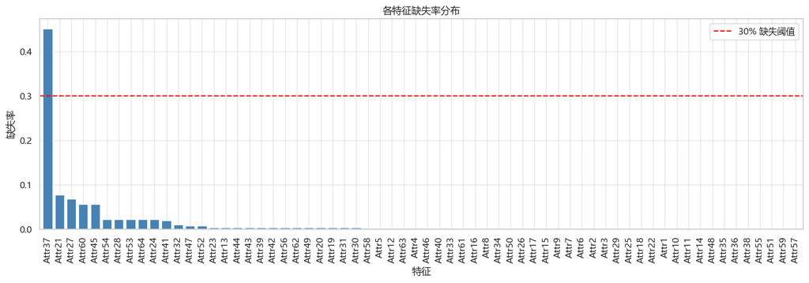

```python
plt.figure(figsize=(14, 5))
missing_pct.plot(kind="bar", color="steelblue", width=0.8)
plt.axhline(y=0.3, color="red", linestyle="--", label="30% 缺失阈值")
plt.xlabel("特征")
plt.ylabel("缺失率")
plt.title("各特征缺失率分布")
plt.legend()
plt.tight_layout()
plt.show()
```

### 2.4 数据预处理

对于缺失值，我们采用 **中位数填充（Median Imputation）** 策略。中位数比均值更鲁棒，不容易受极端值的影响——而财务数据中经常出现极端值（如即将破产的企业可能有极端的负债率）。

同时，我们裁剪极端异常值，避免其对 Logistic 回归和 SVM 产生过大影响。

```python
# 分离特征和目标变量
X = df.drop(columns=[target_col]).copy()
y = df[target_col].astype(int).values  # 0=存续, 1=破产

print(f"目标编码：0=存续, 1=破产")
print(f"破产样本数：{y.sum()}, 存续样本数：{(y == 0).sum()}")
```

```
目标编码：0=存续, 1=破产
破产样本数：495, 存续样本数：10008
```

使用中位数填充缺失值：

```python
# 使用中位数填充缺失值
imputer = SimpleImputer(strategy="median")
X_imputed = pd.DataFrame(
    imputer.fit_transform(X), columns=X.columns, index=X.index
)

print(f"填充后缺失值总数：{X_imputed.isnull().sum().sum()}")
```

```
填充后缺失值总数：0
```

裁剪极端异常值（Winsorize），将每个特征的值限制在 1st–99th 百分位之间：

```python
# 对每个特征进行 Winsorize 处理
for col in X_imputed.columns:
    lower = X_imputed[col].quantile(0.01)
    upper = X_imputed[col].quantile(0.99)
    X_imputed[col] = X_imputed[col].clip(lower, upper)

print("异常值裁剪完成。")
print(f"处理后特征矩阵维度：{X_imputed.shape}")
display(X_imputed.describe().T.head(10))
```

```
异常值裁剪完成。
处理后特征矩阵维度：(10503, 64)
```

|  | count | mean | std | min | 25% | 50% | 75% | max |
| --- | --- | --- | --- | --- | --- | --- | --- | --- |
| Attr1 | 10503.0 | 0.050280 | 0.175869 | -0.678828 | 0.000686 | 0.043034 | 0.123805 | 0.599850 |
| Attr2 | 10503.0 | 0.509406 | 0.354269 | 0.016929 | 0.253955 | 0.464140 | 0.689330 | 2.156092 |
| Attr3 | 10503.0 | 0.198863 | 0.338106 | -1.088166 | 0.017461 | 0.198560 | 0.419545 | 0.901196 |
| Attr4 | 10503.0 | 3.120976 | 5.154966 | 0.187623 | 1.040900 | 1.605600 | 2.952450 | 39.145160 |
| Attr5 | 10503.0 | 4.837171 | 589.770007 | -3205.958000 | -51.961500 | 1.579300 | 55.883500 | 3347.434000 |
| Attr6 | 10503.0 | -0.000346 | 0.352282 | -2.098548 | 0.000000 | 0.000000 | 0.072584 | 0.839455 |
| Attr7 | 10503.0 | 0.063173 | 0.187482 | -0.670175 | 0.002118 | 0.050945 | 0.142275 | 0.675924 |
| Attr8 | 10503.0 | 3.089506 | 6.461000 | -0.545698 | 0.431935 | 1.111000 | 2.850750 | 47.454740 |
| Attr9 | 10503.0 | 1.694354 | 1.244360 | 0.084126 | 1.011350 | 1.199000 | 2.059000 | 7.578854 |
| Attr10 | 10503.0 | 0.474215 | 0.353861 | -1.174664 | 0.297340 | 0.515500 | 0.725635 | 0.980387 |

### 2.5 划分训练集与测试集

```python
X_train, X_test, y_train, y_test = train_test_split(
    X_imputed, y, test_size=0.2, random_state=42, stratify=y,
)

print(f"训练集大小：{X_train.shape[0]}")
print(f"测试集大小：{X_test.shape[0]}")
print(f"训练集破产比例：{y_train.mean():.4f}")
print(f"测试集破产比例：{y_test.mean():.4f}")
```

```
训练集大小：8402
测试集大小：2101
训练集破产比例：0.0471
测试集破产比例：0.0471
```

## 3. 核心概念

### 3.1 Logistic 回归（Logit 模型）

Logistic 回归是金融领域最经典的信用风险模型，其核心思想是：

$$P(\text{破产} = 1 \mid \mathbf{x}) = \frac{1}{1 + e^{-(\beta_0 + \beta_1 x_1 + \cdots + \beta_p x_p)}}$$

**关键优势：系数可直接解释。**

- $\beta_i > 0$：该指标越大，破产概率越高（如负债率）。
- $\beta_i < 0$：该指标越大，破产概率越低（如利润率）。
- $e^{\beta_i}$ 是优势比（Odds Ratio），表示该指标每增加一个单位，破产的"赔率"变化多少倍。

这种可解释性使 Logistic 回归至今仍是巴塞尔协议框架下的标准模型。

### 3.2 支持向量机（SVM）

SVM 的核心思想是寻找一个**最大间隔超平面**，使得两类样本之间的"距离"最大。

- **线性 SVM**：当数据线性可分时直接找超平面。
- **核 SVM（Kernel SVM）**：使用核函数（如 RBF）将数据映射到高维空间，在高维空间中找线性分离面。

**注意**：SVM 对特征尺度非常敏感，因此必须先进行标准化（StandardScaler）。

### 3.3 随机森林与 XGBoost

（与实验 1 类似，此处简要回顾）

- **随机森林**：通过 Bagging 策略并行训练多棵决策树，降低方差。对缺失值和异常值鲁棒。
- **XGBoost**：通过梯度提升串行训练，每棵新树拟合前一轮的残差。支持正则化，内置缺失值处理。

### 3.4 类别不平衡问题

本数据集中破产企业仅占约 5%，这是典型的 **类别不平衡（Class Imbalance）** 问题。如果不加处理，模型会倾向于将所有样本预测为"存续"，获得 ~95% 的准确率但完全无法识别破产企业。

**应对策略**：

- **class_weight="balanced"**：自动根据类别频率调整损失函数中的权重，少数类获得更高权重。
- **scale_pos_weight**（XGBoost 专用）：直接设置正类权重比例。
- **评估指标选择**：放弃 Accuracy，重点关注 AUC-ROC、Recall 和 F1。

## 4. 构建 Logistic 回归模型

### 4.1 训练 Logistic 回归

Logistic 回归要求特征尺度一致，因此我们使用 `Pipeline` 将 StandardScaler 和 LogisticRegression 组合在一起。

```python
# Ref: https://scikit-learn.org/stable/modules/generated/sklearn.linear_model.LogisticRegression.html
logit_clf = make_pipeline(
    StandardScaler(),
    LogisticRegression(
        max_iter=1000,
        class_weight="balanced",  # 处理类别不平衡
        C=1.0,                    # 正则化强度（越小正则化越强）
        solver="lbfgs",
        random_state=42,
    ),
)
logit_clf.fit(X_train, y_train)

y_pred_logit = logit_clf.predict(X_test)
y_prob_logit = logit_clf.predict_proba(X_test)[:, 1]

print("=== Logistic 回归模型评估 ===")
print(classification_report(y_test, y_pred_logit, target_names=["存续", "破产"]))
print(f"AUC-ROC: {roc_auc_score(y_test, y_prob_logit):.4f}")
```

```
=== Logistic 回归模型评估 ===
              precision    recall  f1-score   support

          存续       0.98      0.71      0.82      2002
          破产       0.10      0.67      0.18        99

    accuracy                           0.71      2101
   macro avg       0.54      0.69      0.50      2101
weighted avg       0.94      0.71      0.79      2101

AUC-ROC: 0.7446
```

### 4.2 Logistic 回归系数解读

Logistic 回归最大的价值在于系数的可解释性。系数绝对值越大，对预测破产的影响越大；符号决定影响方向。

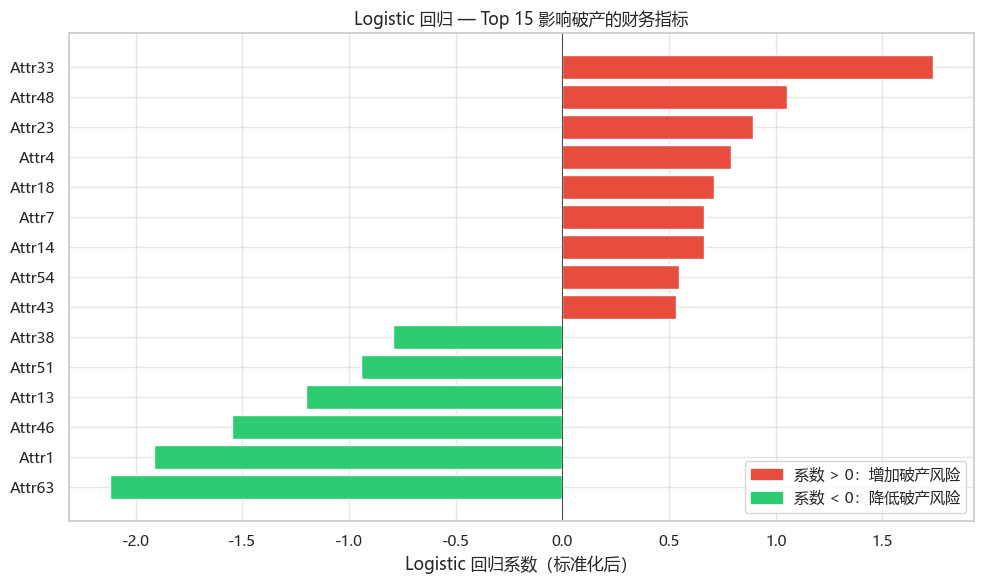

```python
# 提取系数
logit_model = logit_clf.named_steps["logisticregression"]
coef_series = pd.Series(logit_model.coef_[0], index=X_train.columns)

# 取绝对值最大的 Top 15 特征
top_features = coef_series.abs().sort_values(ascending=False).head(15)
top_coefs = coef_series[top_features.index].sort_values()

plt.figure(figsize=(10, 6))
colors = ["#e74c3c" if v > 0 else "#2ecc71" for v in top_coefs.values]
plt.barh(top_coefs.index, top_coefs.values, color=colors)
plt.xlabel("Logistic 回归系数（标准化后）")
plt.title("Logistic 回归 — Top 15 影响破产的财务指标")
plt.axvline(x=0, color="black", linewidth=0.5)

# 添加图例说明
import matplotlib.patches as mpatches
red_patch = mpatches.Patch(color="#e74c3c", label="系数 > 0：增加破产风险")
green_patch = mpatches.Patch(color="#2ecc71", label="系数 < 0：降低破产风险")
plt.legend(handles=[red_patch, green_patch], loc="lower right")

plt.tight_layout()
plt.show()
```

> **如何解读？** 红色条代表该指标值越高、企业破产风险越大（如负债类指标）；绿色条代表该指标值越高、破产风险越低（如盈利类指标）。

## 5. 构建 SVM 模型

### 5.1 训练 SVM

SVM 对特征尺度敏感，同样需要先标准化。我们使用 RBF 核函数，并启用 `probability=True` 以获取概率估计（用于计算 AUC）。

**注意**：SVM 在大样本数据上训练较慢（时间复杂度约 $O(n^2)$ 到 $O(n^3)$），因此对于本数据集（~10000 样本），训练可能需要几分钟。

```python
# Ref: https://scikit-learn.org/stable/modules/generated/sklearn.svm.SVC.html
svm_clf = make_pipeline(
    StandardScaler(),
    SVC(
        kernel="rbf",
        C=1.0,
        gamma="scale",
        class_weight="balanced",
        probability=True,   # 启用概率估计（用于 AUC 计算）
        random_state=42,
    ),
)
svm_clf.fit(X_train, y_train)

y_pred_svm = svm_clf.predict(X_test)
y_prob_svm = svm_clf.predict_proba(X_test)[:, 1]

print("=== SVM 模型评估 ===")
print(classification_report(y_test, y_pred_svm, target_names=["存续", "破产"]))
print(f"AUC-ROC: {roc_auc_score(y_test, y_prob_svm):.4f}")
```

```
=== SVM 模型评估 ===
              precision    recall  f1-score   support

          存续       0.97      0.78      0.86      2002
          破产       0.11      0.53      0.18        99

    accuracy                           0.77      2101
   macro avg       0.54      0.65      0.52      2101
weighted avg       0.93      0.77      0.83      2101

AUC-ROC: 0.7234
```

## 6. 构建随机森林模型

### 6.1 训练随机森林

```python
# Ref: https://scikit-learn.org/stable/modules/generated/sklearn.ensemble.RandomForestClassifier.html
rf_clf = RandomForestClassifier(
    n_estimators=300,
    max_depth=10,
    max_features="sqrt",
    random_state=42,
    class_weight="balanced",
    n_jobs=-1,
)
rf_clf.fit(X_train, y_train)

y_pred_rf = rf_clf.predict(X_test)
y_prob_rf = rf_clf.predict_proba(X_test)[:, 1]

print("=== 随机森林模型评估 ===")
print(classification_report(y_test, y_pred_rf, target_names=["存续", "破产"]))
print(f"AUC-ROC: {roc_auc_score(y_test, y_prob_rf):.4f}")
```

```
=== 随机森林模型评估 ===
              precision    recall  f1-score   support

          存续       0.97      0.98      0.98      2002
          破产       0.51      0.34      0.41        99

    accuracy                           0.95      2101
   macro avg       0.74      0.66      0.69      2101
weighted avg       0.95      0.95      0.95      2101

AUC-ROC: 0.8583
```

## 7. 构建 XGBoost 模型

### 7.1 训练 XGBoost

```python
# 计算正负样本比例
neg_count = (y_train == 0).sum()
pos_count = (y_train == 1).sum()
scale_ratio = neg_count / pos_count

print(f"存续企业数：{neg_count}, 破产企业数：{pos_count}, 比例：{scale_ratio:.2f}")
```

```
存续企业数：8006, 破产企业数：396, 比例：20.22
```

```python
# Ref: https://xgboost.readthedocs.io/en/stable/parameter.html
xgb_clf = xgb.XGBClassifier(
    n_estimators=300,
    max_depth=6,
    learning_rate=0.1,
    scale_pos_weight=scale_ratio,
    eval_metric="logloss",
    random_state=42,
    use_label_encoder=False,
)
xgb_clf.fit(X_train, y_train)

y_pred_xgb = xgb_clf.predict(X_test)
y_prob_xgb = xgb_clf.predict_proba(X_test)[:, 1]

print("=== XGBoost 模型评估 ===")
print(classification_report(y_test, y_pred_xgb, target_names=["存续", "破产"]))
print(f"AUC-ROC: {roc_auc_score(y_test, y_prob_xgb):.4f}")
```

```
=== XGBoost 模型评估 ===
              precision    recall  f1-score   support

          存续       0.97      0.99      0.98      2002
          破产       0.69      0.40      0.51        99

    accuracy                           0.96      2101
   macro avg       0.83      0.70      0.75      2101
weighted avg       0.96      0.96      0.96      2101

AUC-ROC: 0.9205
```

## 8. 模型对比与评估

### 8.1 四模型 ROC 曲线对比

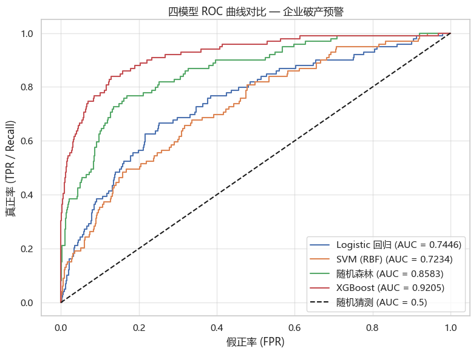

```python
plt.figure(figsize=(8, 6))

models = [
    ("Logistic 回归", y_prob_logit),
    ("SVM (RBF)", y_prob_svm),
    ("随机森林", y_prob_rf),
    ("XGBoost", y_prob_xgb),
]

for name, y_prob in models:
    fpr, tpr, _ = roc_curve(y_test, y_prob)
    auc_val = roc_auc_score(y_test, y_prob)
    plt.plot(fpr, tpr, label=f"{name} (AUC = {auc_val:.4f})")

plt.plot([0, 1], [0, 1], "k--", label="随机猜测 (AUC = 0.5)")
plt.xlabel("假正率 (FPR)")
plt.ylabel("真正率 (TPR / Recall)")
plt.title("四模型 ROC 曲线对比 — 企业破产预警")
plt.legend(loc="lower right")
plt.tight_layout()
plt.show()
```

### 8.2 评估指标汇总

```python
results = []
for name, y_pred, y_prob in [
    ("Logistic 回归", y_pred_logit, y_prob_logit),
    ("SVM (RBF)", y_pred_svm, y_prob_svm),
    ("随机森林", y_pred_rf, y_prob_rf),
    ("XGBoost", y_pred_xgb, y_prob_xgb),
]:
    results.append({
        "模型": name,
        "Accuracy": round(accuracy_score(y_test, y_pred), 4),
        "Precision (破产)": round(precision_score(y_test, y_pred), 4),
        "Recall (破产)": round(recall_score(y_test, y_pred), 4),
        "F1 Score": round(f1_score(y_test, y_pred), 4),
        "AUC-ROC": round(roc_auc_score(y_test, y_prob), 4),
    })

results_df = pd.DataFrame(results)
print("\n=== 四模型评估指标汇总 ===")
display(results_df)
```

```
=== 四模型评估指标汇总 ===
```

|  | 模型 | Accuracy | Precision (破产) | Recall (破产) | F1 Score | AUC-ROC |
| --- | --- | --- | --- | --- | --- | --- |
| 0 | Logistic 回归 | 0.7111 | 0.1031 | 0.6667 | 0.1786 | 0.7446 |
| 1 | SVM (RBF) | 0.7673 | 0.1053 | 0.5253 | 0.1754 | 0.7234 |
| 2 | 随机森林 | 0.9534 | 0.5075 | 0.3434 | 0.4096 | 0.8583 |
| 3 | XGBoost | 0.9634 | 0.6897 | 0.4040 | 0.5096 | 0.9205 |

> **解读指南**：
> - **Accuracy 在本场景中参考价值有限**——因为如果模型把所有企业预测为"存续"，也能获得 ~95% 准确率。
> - **重点看 Recall（破产）**：在所有真正破产的企业中，模型识别出了多少？遗漏一个破产企业的代价远高于误判一个存续企业。
> - **AUC-ROC** 衡量整体区分能力，不受阈值和类别分布影响。

### 8.3 混淆矩阵对比

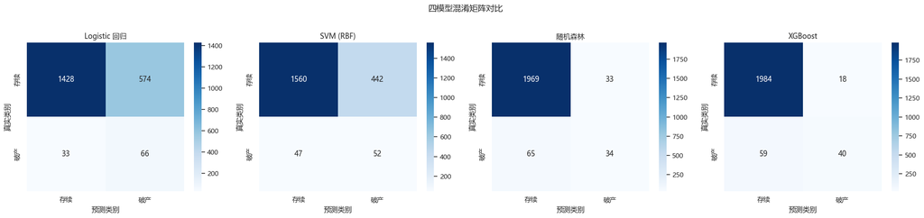

```python
fig, axes = plt.subplots(1, 4, figsize=(22, 5))

for ax, y_pred, name in [
    (axes[0], y_pred_logit, "Logistic 回归"),
    (axes[1], y_pred_svm, "SVM (RBF)"),
    (axes[2], y_pred_rf, "随机森林"),
    (axes[3], y_pred_xgb, "XGBoost"),
]:
    cm = confusion_matrix(y_test, y_pred)
    sns.heatmap(cm, annot=True, fmt="d", cmap="Blues", ax=ax,
                xticklabels=["存续", "破产"], yticklabels=["存续", "破产"])
    ax.set_title(f"{name}")
    ax.set_xlabel("预测类别")
    ax.set_ylabel("真实类别")

plt.suptitle("四模型混淆矩阵对比", fontsize=14, y=1.02)
plt.tight_layout()
plt.show()
```

## 9. 特征重要性与财务指标解释

### 9.1 随机森林 vs XGBoost 特征重要性对比

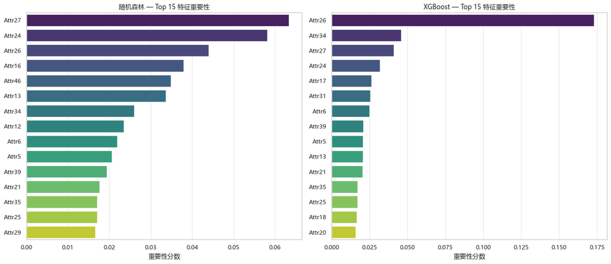

```python
feature_names = X_train.columns.tolist()

rf_importance = pd.Series(rf_clf.feature_importances_, index=feature_names)
xgb_importance = pd.Series(xgb_clf.feature_importances_, index=feature_names)

fig, axes = plt.subplots(1, 2, figsize=(16, 7))

for ax, importance, name in [
    (axes[0], rf_importance, "随机森林"),
    (axes[1], xgb_importance, "XGBoost"),
]:
    top15 = importance.sort_values(ascending=False).head(15)
    sns.barplot(x=top15.values, y=top15.index, ax=ax, palette="viridis")
    ax.set_title(f"{name} — Top 15 特征重要性")
    ax.set_xlabel("重要性分数")
    ax.set_ylabel("")

plt.tight_layout()
plt.show()
```

### 9.2 三种模型的关键变量综合对比

将 Logistic 回归系数绝对值、随机森林重要性、XGBoost 重要性的排名合并，找出一致公认的关键指标。

```python
# 汇总三种模型的排名
rank_logit = coef_series.abs().rank(ascending=False)
rank_rf = rf_importance.rank(ascending=False)
rank_xgb = xgb_importance.rank(ascending=False)

rank_df = pd.DataFrame({
    "Logistic排名": rank_logit,
    "RF排名": rank_rf,
    "XGB排名": rank_xgb,
})
rank_df["平均排名"] = rank_df.mean(axis=1)
rank_df = rank_df.sort_values("平均排名")

print("=== 三模型一致认为最重要的 Top 10 财务指标 ===")
display(rank_df.head(10))
```

```
=== 三模型一致认为最重要的 Top 10 财务指标 ===
```

|  | Logistic排名 | RF排名 | XGB排名 | 平均排名 |
| --- | --- | --- | --- | --- |
| Attr13 | 5.0 | 6.0 | 10.0 | 7.000000 |
| Attr26 | 18.0 | 3.0 | 1.0 | 7.333333 |
| Attr34 | 17.0 | 7.0 | 2.0 | 8.666667 |
| Attr46 | 4.0 | 5.0 | 18.0 | 9.000000 |
| Attr24 | 31.0 | 2.0 | 4.0 | 12.333333 |
| Attr27 | 37.0 | 1.0 | 3.0 | 13.666667 |
| Attr35 | 23.0 | 13.0 | 12.0 | 16.000000 |
| Attr38 | 9.0 | 17.0 | 25.0 | 17.000000 |
| Attr23 | 8.0 | 18.0 | 29.0 | 18.333333 |
| Attr16 | 24.0 | 4.0 | 30.0 | 19.333333 |

### 9.3 关键财务指标的分布对比

选取排名最靠前的 4 个指标，对比破产企业与存续企业的分布差异：

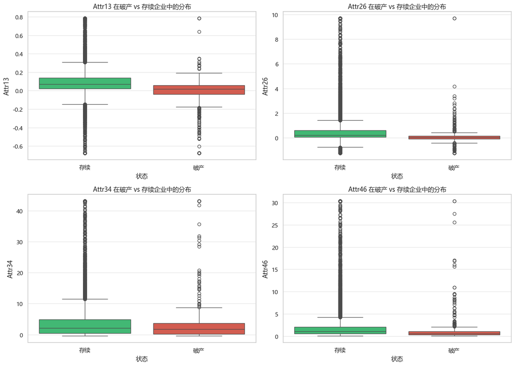

```python
top4_features = rank_df.head(4).index.tolist()

fig, axes = plt.subplots(2, 2, figsize=(14, 10))

for ax, feat in zip(axes.ravel(), top4_features):
    data_plot = pd.DataFrame({
        feat: X_imputed[feat],
        "状态": ["破产" if yi == 1 else "存续" for yi in y],
    })
    sns.boxplot(data=data_plot, x="状态", y=feat, ax=ax, palette={"存续": "#2ecc71", "破产": "#e74c3c"})
    ax.set_title(f"{feat} 在破产 vs 存续企业中的分布")

plt.tight_layout()
plt.show()
```

## 10. 企业破产预警报告

### 10.1 解释性与预测性对比

```python
comparison = pd.DataFrame({
    "模型": ["Logistic 回归", "SVM (RBF)", "随机森林", "XGBoost"],
    "AUC-ROC": [
        round(roc_auc_score(y_test, y_prob_logit), 4),
        round(roc_auc_score(y_test, y_prob_svm), 4),
        round(roc_auc_score(y_test, y_prob_rf), 4),
        round(roc_auc_score(y_test, y_prob_xgb), 4),
    ],
    "Recall (破产)": [
        round(recall_score(y_test, y_pred_logit), 4),
        round(recall_score(y_test, y_pred_svm), 4),
        round(recall_score(y_test, y_pred_rf), 4),
        round(recall_score(y_test, y_pred_xgb), 4),
    ],
})

display(comparison)
```

|  | 模型 | AUC-ROC | Recall (破产) |
| --- | --- | --- | --- |
| 0 | Logistic 回归 | 0.7446 | 0.6667 |
| 1 | SVM (RBF) | 0.7234 | 0.5253 |
| 2 | 随机森林 | 0.8583 | 0.3434 |
| 3 | XGBoost | 0.9205 | 0.4040 |

### 10.2 模拟企业破产预警输出

选取测试集中若干样本，输出每个企业的破产风险评分和预警等级：

```python
# 使用 XGBoost 的概率作为风险评分
sample_idx = np.random.uniform(0, X_test.shape[0], 10).astype(int)
sample_scores = xgb_clf.predict_proba(X_test.iloc[sample_idx, :])[:, 1]

warning_report = pd.DataFrame(
    data={
        "破产概率": [f"{s:.4f}" for s in sample_scores],
        "真实状态": ["破产" if yi == 1 else "存续" for yi in y_test[sample_idx]],
    },
    index=sample_idx
)

display(warning_report)
```

|  | 破产概率 | 真实状态 |
| --- | --- | --- |
| 282 | 0.0001 | 存续 |
| 713 | 0.0022 | 存续 |
| 1137 | 0.0155 | 存续 |
| 265 | 0.7401 | 破产 |
| 628 | 0.0603 | 存续 |
| 670 | 0.0008 | 存续 |
| 1073 | 0.0001 | 存续 |
| 755 | 0.0000 | 存续 |
| 1337 | 0.0001 | 存续 |
| 1972 | 0.0008 | 存续 |

### 10.3 预警阈值分析

不同的预警阈值会影响模型的 Precision 和 Recall 表现。银行需要根据业务需求选择合适的阈值。

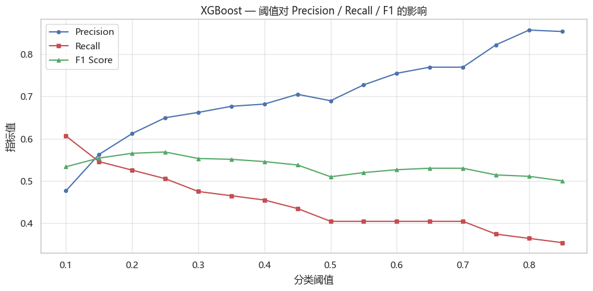

```python
thresholds = np.arange(0.1, 0.9, 0.05)
threshold_results = []

for t in thresholds:
    y_pred_t = (y_prob_xgb >= t).astype(int)
    threshold_results.append({
        "阈值": round(t, 2),
        "Precision": round(precision_score(y_test, y_pred_t, zero_division=0), 4),
        "Recall": round(recall_score(y_test, y_pred_t, zero_division=0), 4),
        "F1": round(f1_score(y_test, y_pred_t, zero_division=0), 4),
    })

thr_df = pd.DataFrame(threshold_results)

plt.figure(figsize=(10, 5))
plt.plot(thr_df["阈值"], thr_df["Precision"], "b-o", label="Precision", markersize=4)
plt.plot(thr_df["阈值"], thr_df["Recall"], "r-s", label="Recall", markersize=4)
plt.plot(thr_df["阈值"], thr_df["F1"], "g-^", label="F1 Score", markersize=4)
plt.xlabel("分类阈值")
plt.ylabel("指标值")
plt.title("XGBoost — 阈值对 Precision / Recall / F1 的影响")
plt.legend()
plt.grid(True)
plt.tight_layout()
plt.show()
```

> **业务决策**：如果银行对破产风险零容忍（宁可多查也不能漏掉），应降低阈值以提高 Recall；如果银行资源有限、不希望误判太多存续企业，应提高阈值以提高 Precision。

## 11. 实验结论

### 11.1 四种模型的比较总结

- **Logistic 回归**：解释性最强，系数直接对应财务指标的影响方向与大小，是监管合规的首选。但在处理非线性关系和特征交互时表现有限。
- **SVM**：在高维空间中寻找最优分离面，理论优美，但在大样本数据上训练较慢，且模型本身缺乏解释性。
- **随机森林**：性能稳健，对异常值和缺失值鲁棒，特征重要性可靠。是"可解释性与预测性"之间的良好折中。
- **XGBoost**：通常预测性能最优，支持正则化和缺失值处理，是工业级风控系统的首选。

### 11.2 关键财务指标的启示

通过三种模型的交叉验证，最重要的财务指标通常包括：

### 11.3 解释性 vs 预测性的取舍

在实际业务中，不存在"一刀切"的最优模型。常见的做法是：

- **对外报告**使用 Logistic 回归（满足监管要求的可解释性）。
- **内部决策**使用 XGBoost（追求最优预测性能）。
- **两者结合**：用 XGBoost 做预测，用 Logistic 回归系数和树模型特征重要性做解释。

## 12. 课堂思考题

1. 在本实验中，如果一个模型 Accuracy = 0.96 但 Recall（破产）= 0.10，你会接受这个模型吗？为什么？
2. Logistic 回归中的正则化参数 `C` 越大越好吗？它与模型过拟合有什么关系？
3. SVM 的 RBF 核中，`gamma` 参数控制什么？过大和过小各会导致什么问题？
4. 为什么三种模型评估出的"最重要特征"排序可能不一致？这说明了什么？
5. 假设你需要向企业管理层汇报破产预警结果，你会如何结合 Logistic 回归的系数和 XGBoost 的预测概率来撰写一份有说服力的报告？